# Project: Investigate a Dataset - [No-show appointments]

- Introduction
- Data Wrangling
- Exploratory Data Analysis
- Conclusions

## Introduction

### Dataset Description

> This dataset collects information from 100k medical appointments in Brazil and is focused on the question of whether or not patients show up for their appointment. A number of characteristics about the patient are included in each row.
> - ScheduledDay; tells us on what day the patient set up their appointment.
> - Neighborhood: indicates the location of the hospital.
> - Scholarship: indicates whether or not the patient is enrolled in Brasilian welfare program Bolsa Família.
> - Gender: tells the Gender of the patient
> - AppointmentDay: tells us the appointment day for the patient.
> - Age: tells us the age of the patient
> - Neighbourhood: tells us the location of the hospital
> - Scholarship: the patient Scholarship or not
> - Hipertension: the patient has Hipertension or not
> - Diabetes: the patient has Diabetes or not
> - Alcoholism: the patient has Alcoholism or not
> - Handcap: the patient has Handcap or not
> - SMS_received: the patient received SMS or not
> - No-show: the patient come or not it says ‘No’ if the patient showed up to their appointment, and ‘Yes’ if they did not show up.

### Question(s) for Analysis

- Age insights ?
- does age has a relation with our target variable?
- Gender insights ?
- does gender has a relation with our target variable ?
- what is the insights in the difference between the AppointmentDay and ScheduledDay ?
- does the difference between the AppointmentDay and ScheduledDay has a relation with our target variable?
- is there a relationship between binary variables scholarship - hypertension - diabetes - alcoholism - handicap - SMS and target variable ?
- the most busy Neighborhood ?

```python
# Use this cell to set up import statements for all of the packages that you
#   plan to use.
import numpy as np
import pandas as pd
import matplotlib.pyplot as plt
import seaborn as sns
sns.set()
# Remember to include a 'magic word' so that your visualizations are plotted
#   inline with the notebook. See this page for more:
#   http://ipython.readthedocs.io/en/stable/interactive/magics.html
%matplotlib inline
```

## Data wrangling

### Load data to dataframe

```python
df = pd.read_csv('./Database_No_show_appointments/noshowappointments-kagglev2-may-2016.csv')
df.head()
```

|  | PatientId | AppointmentID | Gender | ScheduledDay | AppointmentDay | Age | Neighbourhood | Scholarship | Hipertension | Diabetes | Alcoholism | Handcap | SMS_received | No-show |
| --- | --- | --- | --- | --- | --- | --- | --- | --- | --- | --- | --- | --- | --- | --- |
| 0 | 2.987250e+13 | 5642903 | F | 2016-04-29T18:38:08Z | 2016-04-29T00:00:00Z | 62 | JARDIM DA PENHA | 0 | 1 | 0 | 0 | 0 | 0 | No |
| 1 | 5.589978e+14 | 5642503 | M | 2016-04-29T16:08:27Z | 2016-04-29T00:00:00Z | 56 | JARDIM DA PENHA | 0 | 0 | 0 | 0 | 0 | 0 | No |
| 2 | 4.262962e+12 | 5642549 | F | 2016-04-29T16:19:04Z | 2016-04-29T00:00:00Z | 62 | MATA DA PRAIA | 0 | 0 | 0 | 0 | 0 | 0 | No |
| 3 | 8.679512e+11 | 5642828 | F | 2016-04-29T17:29:31Z | 2016-04-29T00:00:00Z | 8 | PONTAL DE CAMBURI | 0 | 0 | 0 | 0 | 0 | 0 | No |
| 4 | 8.841186e+12 | 5642494 | F | 2016-04-29T16:07:23Z | 2016-04-29T00:00:00Z | 56 | JARDIM DA PENHA | 0 | 1 | 1 | 0 | 0 | 0 | No |

```python
# check the shape of the data Rows and colums
Shape = df.shape
print(f"Number of rows: {Shape[0]}")
print(f"Number of colums: {Shape[1]}")
```

```
Number of rows: 110527
Number of colums: 14
```

## Explore each variable (Column name, data type, nulls, missing values)

```python
df.info()
```

```
<class 'pandas.core.frame.DataFrame'>
RangeIndex: 110527 entries, 0 to 110526
Data columns (total 14 columns):
PatientId         110527 non-null float64
AppointmentID     110527 non-null int64
Gender            110527 non-null object
ScheduledDay      110527 non-null object
AppointmentDay    110527 non-null object
Age               110527 non-null int64
Neighbourhood     110527 non-null object
Scholarship       110527 non-null int64
Hipertension      110527 non-null int64
Diabetes          110527 non-null int64
Alcoholism        110527 non-null int64
Handcap           110527 non-null int64
SMS_received      110527 non-null int64
No-show           110527 non-null object
dtypes: float64(1), int64(8), object(5)
memory usage: 11.8+ MB
```

```python
# check for duplicates:
df.duplicated().any()
```

```
False
```

```python
# checking for the missing values:
df.isna().sum().any()
```

```
False
```

## Check the summary statistics for the numerical variables (count, mean, std ect..)

```python
df.describe().T
```

|  | count | mean | std | min | 25% | 50% | 75% | max |
| --- | --- | --- | --- | --- | --- | --- | --- | --- |
| PatientId | 110527.0 | 1.474963e+14 | 2.560949e+14 | 3.921784e+04 | 4.172614e+12 | 3.173184e+13 | 9.439172e+13 | 9.999816e+14 |
| AppointmentID | 110527.0 | 5.675305e+06 | 7.129575e+04 | 5.030230e+06 | 5.640286e+06 | 5.680573e+06 | 5.725524e+06 | 5.790484e+06 |
| Age | 110527.0 | 3.708887e+01 | 2.311020e+01 | -1.000000e+00 | 1.800000e+01 | 3.700000e+01 | 5.500000e+01 | 1.150000e+02 |
| Scholarship | 110527.0 | 9.826558e-02 | 2.976748e-01 | 0.000000e+00 | 0.000000e+00 | 0.000000e+00 | 0.000000e+00 | 1.000000e+00 |
| Hipertension | 110527.0 | 1.972459e-01 | 3.979213e-01 | 0.000000e+00 | 0.000000e+00 | 0.000000e+00 | 0.000000e+00 | 1.000000e+00 |
| Diabetes | 110527.0 | 7.186479e-02 | 2.582651e-01 | 0.000000e+00 | 0.000000e+00 | 0.000000e+00 | 0.000000e+00 | 1.000000e+00 |
| Alcoholism | 110527.0 | 3.039981e-02 | 1.716856e-01 | 0.000000e+00 | 0.000000e+00 | 0.000000e+00 | 0.000000e+00 | 1.000000e+00 |
| Handcap | 110527.0 | 2.224796e-02 | 1.615427e-01 | 0.000000e+00 | 0.000000e+00 | 0.000000e+00 | 0.000000e+00 | 4.000000e+00 |
| SMS_received | 110527.0 | 3.210256e-01 | 4.668727e-01 | 0.000000e+00 | 0.000000e+00 | 0.000000e+00 | 1.000000e+00 | 1.000000e+00 |

## check for unique values in each column

```python
df.nunique()
```

```
PatientId          62299
AppointmentID     110527
Gender                 2
ScheduledDay      103549
AppointmentDay        27
Age                  104
Neighbourhood         81
Scholarship            2
Hipertension           2
Diabetes               2
Alcoholism             2
Handcap                5
SMS_received           2
No-show                2
dtype: int64
```

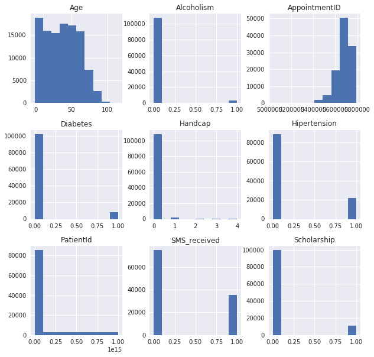

```python
df.hist(figsize=(10,10));
```

## Conclusions From the previous summaries of the data:

> - PatientId < Number of the rows and (AppointmentID) which mean Patient has many to one relationship one Patient has many Appointmen.
> - Scholarship, Hipertension, Diabetes, Alcoholism, SMS_received are binary varible (0 or 1)
> - Handcap ranged from 0 to 4
> - Gender are binary varible (Male or Fimale)
> - No-show the target varible (Yes or No)
> - Age has min value of -1
> - ScheduledDay, AppointmentDay strings not datatime due to CSV conversion
> - There is no missing values or Nulls

## Data Cleaning

### Copy a version of the dataframe to change it safely

```python
df_new = df.copy()
df_new.head()
```

|  | PatientId | AppointmentID | Gender | ScheduledDay | AppointmentDay | Age | Neighbourhood | Scholarship | Hipertension | Diabetes | Alcoholism | Handcap | SMS_received | No-show |
| --- | --- | --- | --- | --- | --- | --- | --- | --- | --- | --- | --- | --- | --- | --- |
| 0 | 2.987250e+13 | 5642903 | F | 2016-04-29T18:38:08Z | 2016-04-29T00:00:00Z | 62 | JARDIM DA PENHA | 0 | 1 | 0 | 0 | 0 | 0 | No |
| 1 | 5.589978e+14 | 5642503 | M | 2016-04-29T16:08:27Z | 2016-04-29T00:00:00Z | 56 | JARDIM DA PENHA | 0 | 0 | 0 | 0 | 0 | 0 | No |
| 2 | 4.262962e+12 | 5642549 | F | 2016-04-29T16:19:04Z | 2016-04-29T00:00:00Z | 62 | MATA DA PRAIA | 0 | 0 | 0 | 0 | 0 | 0 | No |
| 3 | 8.679512e+11 | 5642828 | F | 2016-04-29T17:29:31Z | 2016-04-29T00:00:00Z | 8 | PONTAL DE CAMBURI | 0 | 0 | 0 | 0 | 0 | 0 | No |
| 4 | 8.841186e+12 | 5642494 | F | 2016-04-29T16:07:23Z | 2016-04-29T00:00:00Z | 56 | JARDIM DA PENHA | 0 | 1 | 1 | 0 | 0 | 0 | No |

### drop Age of -1 value

```python
df_new.drop(df_new[df_new['Age'] < 0].index, inplace = True)
```

### Convert to binary as from 1 to 4 has very low percentage

```python
df_new['Handcap'] = df_new['Handcap'].apply(lambda x: 0 if x == 0 else 1)
```

### Convert Gender to binary 0 -> Female and 1 -> Male

```python
df_new["Gender"].replace(to_replace=['F', 'M'], value=[0, 1], inplace=True)
df_new["Gender"][:3]
```

```
0    0
1    1
2    0
Name: Gender, dtype: int64
```

### Convert No-show to binary 0 -> not show and 1 -> show

```python
df_new["No-show"].replace(to_replace=['Yes', 'No'], value=[0, 1], inplace=True)
```

```python
df_new[df_new["No-show"] == 0].count()
```

```
PatientId         22319
AppointmentID     22319
Gender            22319
ScheduledDay      22319
AppointmentDay    22319
Age               22319
Neighbourhood     22319
Scholarship       22319
Hipertension      22319
Diabetes          22319
Alcoholism        22319
Handcap           22319
SMS_received      22319
No-show           22319
dtype: int64
```

### Convert Ids to strings

```python
df_new['PatientId'] = df_new['PatientId'].apply(int).apply(str)
df_new['AppointmentID'] = df_new['AppointmentID'].apply(str)
```

### Convert Data from string to Datatime to apply its functions

```python
df_new['ScheduledDay'] = pd.to_datetime(df_new['ScheduledDay']).dt.strftime('%Y-%m-%d')
df_new['ScheduledDay'] = pd.to_datetime(df_new['ScheduledDay'])
df_new['ScheduledDay'] = df_new['ScheduledDay'].apply(lambda d: d.replace(tzinfo=None))

df_new['AppointmentDay'] = pd.to_datetime(df_new['AppointmentDay'])
df_new['AppointmentDay'] = df_new['AppointmentDay'].apply(lambda v: v.replace(tzinfo=None))
```

### Calculating the difference between the Appointment date and Scheduled data (as it's a good indicator)

```python
df_new['day_diff'] = (df_new['AppointmentDay'] - df_new['ScheduledDay']).dt.days
```

```python
df_new.head(2)
```

|  | PatientId | AppointmentID | Gender | ScheduledDay | AppointmentDay | Age | Neighbourhood | Scholarship | Hipertension | Diabetes | Alcoholism | Handcap | SMS_received | No-show | day_diff |
| --- | --- | --- | --- | --- | --- | --- | --- | --- | --- | --- | --- | --- | --- | --- | --- |
| 0 | 29872499824296 | 5642903 | 0 | 2016-04-29 | 2016-04-29 | 62 | JARDIM DA PENHA | 0 | 1 | 0 | 0 | 0 | 0 | 1 | 0 |
| 1 | 558997776694438 | 5642503 | 1 | 2016-04-29 | 2016-04-29 | 56 | JARDIM DA PENHA | 0 | 0 | 0 | 0 | 0 | 0 | 1 | 0 |

```python
df_new.info()
```

```
<class 'pandas.core.frame.DataFrame'>
Int64Index: 110526 entries, 0 to 110526
Data columns (total 15 columns):
PatientId         110526 non-null object
AppointmentID     110526 non-null object
Gender            110526 non-null int64
ScheduledDay      110526 non-null datetime64[ns]
AppointmentDay    110526 non-null datetime64[ns]
Age               110526 non-null int64
Neighbourhood     110526 non-null object
Scholarship       110526 non-null int64
Hipertension      110526 non-null int64
Diabetes          110526 non-null int64
Alcoholism        110526 non-null int64
Handcap           110526 non-null int64
SMS_received      110526 non-null int64
No-show           110526 non-null int64
day_diff          110526 non-null int64
dtypes: datetime64[ns](2), int64(10), object(3)
memory usage: 13.5+ MB
```

```python
df_new.describe().T
```

|  | count | mean | std | min | 25% | 50% | 75% | max |
| --- | --- | --- | --- | --- | --- | --- | --- | --- |
| Gender | 110526.0 | 0.350026 | 0.476980 | 0.0 | 0.0 | 0.0 | 1.0 | 1.0 |
| Age | 110526.0 | 37.089219 | 23.110026 | 0.0 | 18.0 | 37.0 | 55.0 | 115.0 |
| Scholarship | 110526.0 | 0.098266 | 0.297676 | 0.0 | 0.0 | 0.0 | 0.0 | 1.0 |
| Hipertension | 110526.0 | 0.197248 | 0.397923 | 0.0 | 0.0 | 0.0 | 0.0 | 1.0 |
| Diabetes | 110526.0 | 0.071865 | 0.258266 | 0.0 | 0.0 | 0.0 | 0.0 | 1.0 |
| Alcoholism | 110526.0 | 0.030400 | 0.171686 | 0.0 | 0.0 | 0.0 | 0.0 | 1.0 |
| Handcap | 110526.0 | 0.020276 | 0.140943 | 0.0 | 0.0 | 0.0 | 0.0 | 1.0 |
| SMS_received | 110526.0 | 0.321029 | 0.466874 | 0.0 | 0.0 | 0.0 | 1.0 | 1.0 |
| No-show | 110526.0 | 0.798066 | 0.401445 | 0.0 | 1.0 | 1.0 | 1.0 | 1.0 |
| day_diff | 110526.0 | 10.183794 | 15.255034 | -6.0 | 0.0 | 4.0 | 15.0 | 179.0 |

### from the describe we found day_diff has - values we should remove

```python
df_new.drop(df_new[df_new['day_diff'] < 0].index, inplace = True)
df_new.describe().T
```

|  | count | mean | std | min | 25% | 50% | 75% | max |
| --- | --- | --- | --- | --- | --- | --- | --- | --- |
| Gender | 110521.0 | 0.350024 | 0.476979 | 0.0 | 0.0 | 0.0 | 1.0 | 1.0 |
| Age | 110521.0 | 37.089386 | 23.109885 | 0.0 | 18.0 | 37.0 | 55.0 | 115.0 |
| Scholarship | 110521.0 | 0.098271 | 0.297682 | 0.0 | 0.0 | 0.0 | 0.0 | 1.0 |
| Hipertension | 110521.0 | 0.197257 | 0.397929 | 0.0 | 0.0 | 0.0 | 0.0 | 1.0 |
| Diabetes | 110521.0 | 0.071869 | 0.258272 | 0.0 | 0.0 | 0.0 | 0.0 | 1.0 |
| Alcoholism | 110521.0 | 0.030401 | 0.171690 | 0.0 | 0.0 | 0.0 | 0.0 | 1.0 |
| Handcap | 110521.0 | 0.020259 | 0.140884 | 0.0 | 0.0 | 0.0 | 0.0 | 1.0 |
| SMS_received | 110521.0 | 0.321043 | 0.466879 | 0.0 | 0.0 | 0.0 | 1.0 | 1.0 |
| No-show | 110521.0 | 0.798102 | 0.401419 | 0.0 | 1.0 | 1.0 | 1.0 | 1.0 |
| day_diff | 110521.0 | 10.184345 | 15.255153 | 0.0 | 0.0 | 4.0 | 15.0 | 179.0 |

```python
# After discussing the structure of the data and any problems that need to be
#   cleaned, perform those cleaning steps in the second part of this section.
show = df_new["No-show"] == 1
not_show = df_new["No-show"] == 0
df_new.Age[not_show].count()
```

```
22314
```

## Exploratory Data Analysis

### Research Question 1 (what are the Age insights?)

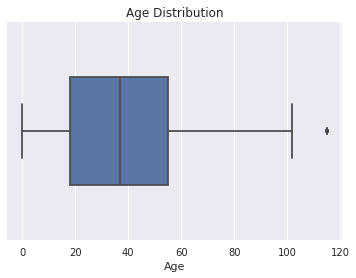

```python
ax = sns.boxplot(x="Age", data=df_new,width=.5);
ax.set(xlabel='Age', title="Age Distribution");
```

```python
df_new['Age'].describe()
```

```
count    110521.000000
mean         37.089386
std          23.109885
min           0.000000
25%          18.000000
50%          37.000000
75%          55.000000
max         115.000000
Name: Age, dtype: float64
```

> - the mean age is 37
> - it's a right-skewed distribution
> - 50% of patients ages between 18 and 55

### Research Question 2 (does age has a relation with our target variable?)

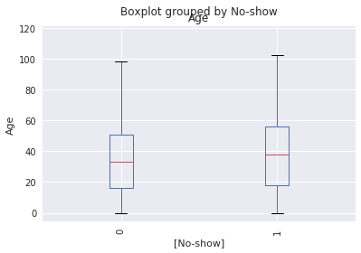

```python
df_new.boxplot(column= ['Age'],by = ['No-show'],rot = 90);
plt.ylabel("Age");
```

```python
df_new.groupby('No-show')['Age'].agg(["mean","std"])
```

| No-show | mean | std |
| --- | --- | --- |
| 0 | 34.317872 | 21.965009 |
| 1 | 37.790504 | 23.338645 |

> truly, I can't find a significant indicator that makes Age affect the target variable directly as the mean and the Std are almost the same.

### Research Question 3 (what are the Gender insights?)

```
F    64.997602
M    35.002398
Name: Gender, dtype: float64
```

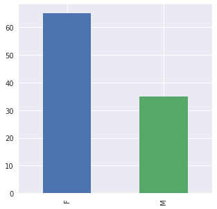

```python
Gender_percentages = df_new["Gender"].value_counts(normalize=True) * 100
Gender_percentages.index = ['F',"M"]
Gender_percentages.plot.bar(figsize=(5, 5));
Gender_percentages
```

> - Female, Male percentages in data are 65, 35%

### Visualize the relation between Gender and age

```python
def Age_gender_relation(lower_age, high_age,df):
    return df[(df["Age"] <high_age) & (df["Age"] >=(lower_age))].groupby(["Gender"]).count()['PatientId']
```

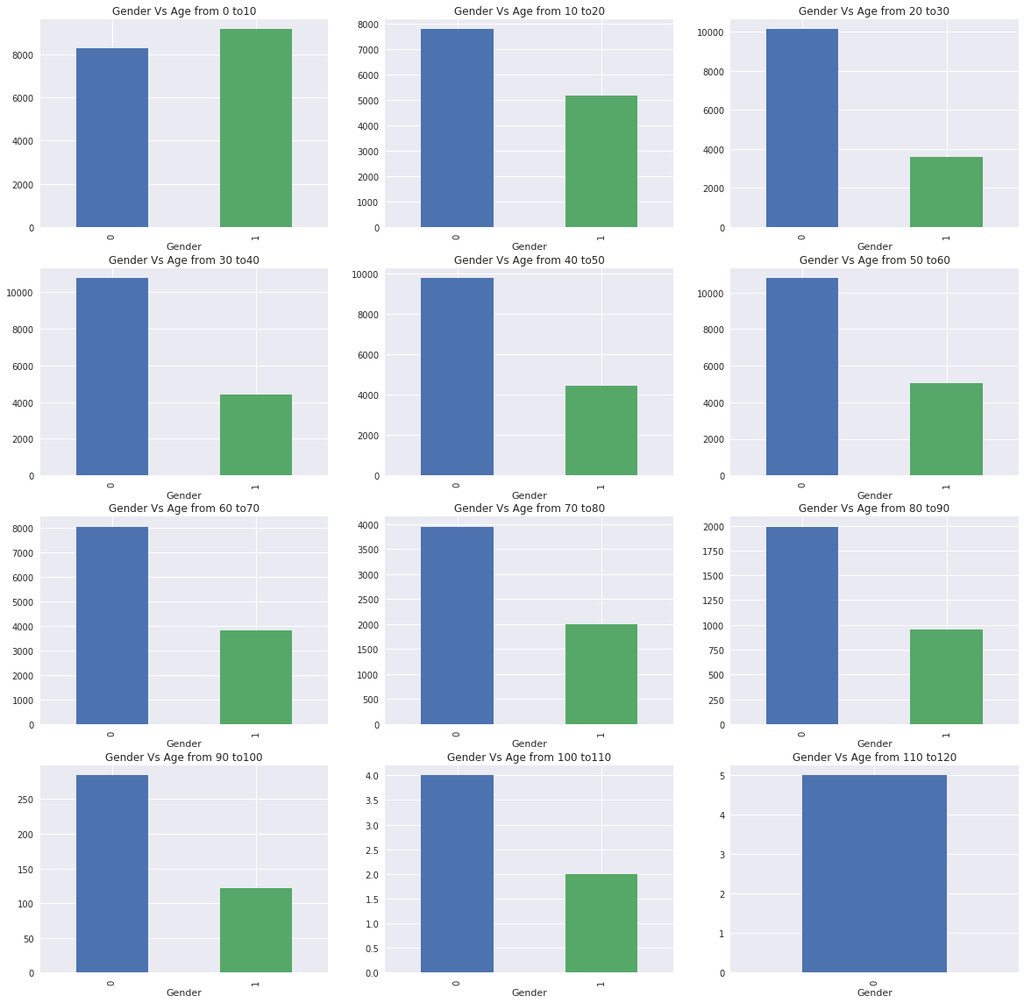

```python
fig, axes = plt.subplots(nrows=4, ncols=3,figsize=(20,20))
Age_range = 0
for i in range(4):
    for j in range(3):
        Age_gender_relation(Age_range,Age_range+10,df_new).plot(ax=axes[i,j], kind='bar',title=f"Gender Vs Age from {Age_range} to{Age_range+10}")
        Age_range+=10
```

### Research Question 4 (does gender has a relation with our target variable?)

### The ratio of women to go at the time

```python
(df_new.groupby(["Gender","No-show"]).count()['PatientId']).loc[0].transform(lambda x: (x) / x.sum())*100
```

```
No-show
0    20.311543
1    79.688457
Name: PatientId, dtype: float64
```

```python
(df_new.groupby(["Gender","No-show"]).count()['PatientId']).loc[1].transform(lambda x: (x) / x.sum())*100
```

```
No-show
0    19.96381
1    80.03619
Name: PatientId, dtype: float64
```

> - as both ratios are almost the same 80% go at the time then there is no clear relation between Gender and the target variable.

### Research Question 5 (the insights into the difference between the Appointment Day and Scheduled Day?)

#### Plot the Box plot for Day_diff variable

```
25%      0.0
50%      4.0
75%     15.0
max    179.0
Name: day_diff, dtype: float64
```

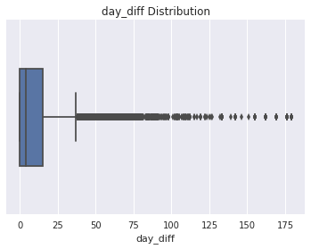

```python
ax = sns.boxplot(x="day_diff", data=df_new,width=.5);
ax.set(xlabel='day_diff', title="day_diff Distribution");
df_new["day_diff"].describe()[['25%','50%','75%',"max"]]
```

#### Calculate the percentage of patients who make appointments on the same day

```python
#df_new[(df_new["day_diff"] <1)].count()
(df_new.groupby(["day_diff"]).count()["Gender"].transform(lambda x: (x) / x.sum())*100)[0]
```

```
34.891106667511153
```

### Research Question 6 (the insights into the difference between the Appointment Day and Scheduled Day?)

```python
def diff_show_relation(lower_bound, higher_bound,df,Column,Groupby):
    return df[(df[Column] <=higher_bound) & (df[Column] >=(lower_bound))].groupby([Groupby]).count()['PatientId'].transform(lambda x: (x) / x.sum())*100
```

##### Plot (Show) VS Day_diff to find the relation between them

| No-show | same day | within 15 days | After 15 days |
| --- | --- | --- | --- |
| 0 | 4.647062 | 26.115109 | 32.705936 |
| 1 | 95.352938 | 73.884891 | 67.294064 |

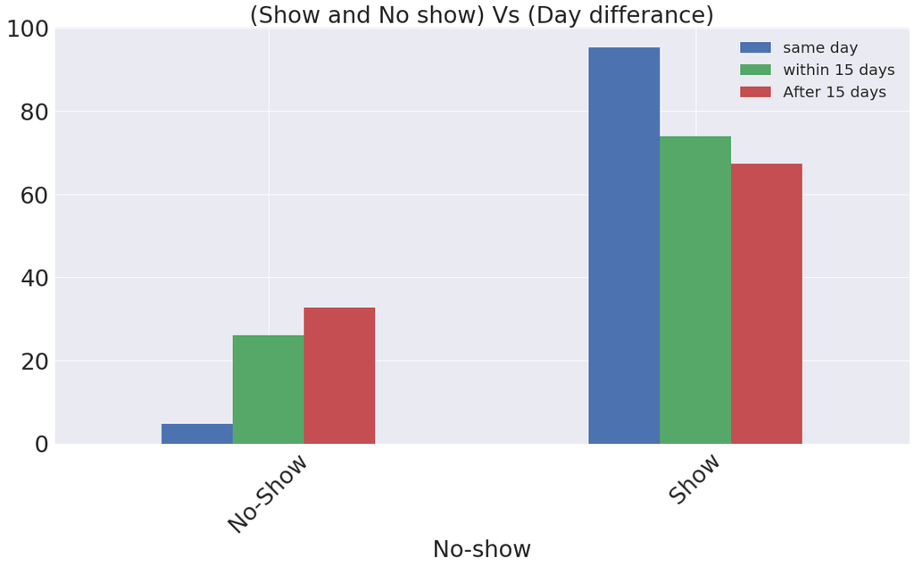

```python
diff_show = pd.DataFrame({"same day":diff_show_relation(0,0,df_new,"day_diff","No-show"),
"within 15 days":diff_show_relation(1,15,df_new,"day_diff","No-show"),
"After 15 days":diff_show_relation(16,180,df_new,"day_diff","No-show")})
ax = diff_show.plot(kind="bar",figsize=(20,10),xticks =[1,2],fontsize =30)
ax.set_title("(Show and No show) Vs (Day differance)", fontsize=30)
ax.set_xticklabels(['No-Show', 'Show'], rotation=45)
ax.legend(fontsize=20)
ax.xaxis.label.set_size(30)
diff_show
```

> - On the same day, 95% of patients come on the time
> - Within 15 days, 5 74% of the patients come on the time
> - After 15 days, 67.3% of the patient come on the time

```python
def drow_binaryList(col_to_plot):
    fig, axs = plt.subplots(3, 2, figsize=(20, 20))
    for col, ax in zip(col_to_plot[:len(col_to_plot)//2], axs[:,0]):
        sns.countplot(x=col, data=df_new, ax=ax)
    for col, ax in zip(col_to_plot[len(col_to_plot)//2:], axs[:,1]):
        sns.countplot(x=col, data=df_new, ax=ax)
```

##### Plot the count plot for the binary categorical variable

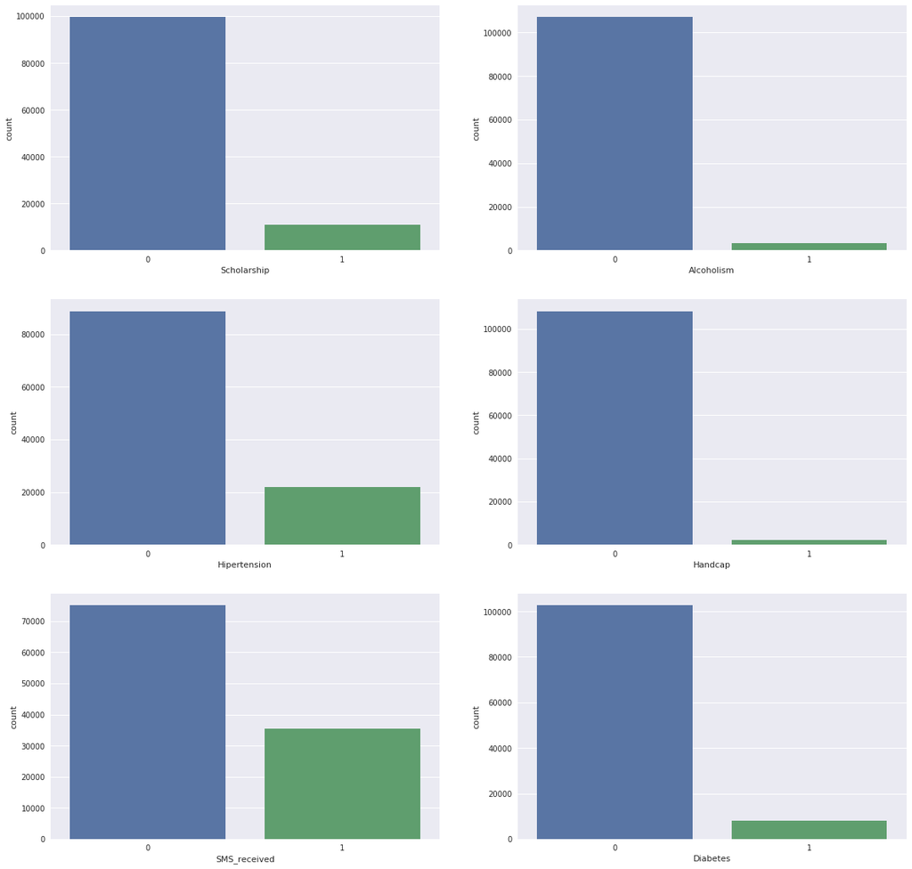

```python
col_of_binary = ["Scholarship","Hipertension","SMS_received","Alcoholism","Handcap","Diabetes"]
drow_binaryList(col_of_binary)
```

#### Calculate the percentage of the binary variable to be true in the data.

```python
BinaryCategorical_presentage = df_new[col_of_binary].stack(level=0)
BinaryCategorical_presentage = pd.DataFrame(BinaryCategorical_presentage)
BinaryCategorical_presentage.reset_index(drop=False, inplace =True)
BinaryCategorical_presentage
BinaryCategorical_presentage.columns = ['Nothing', 'BinaryCategorical', 'value']
(BinaryCategorical_presentage.groupby('BinaryCategorical')['value'].sum() / BinaryCategorical_presentage["BinaryCategorical"].value_counts()) * 100
```

```
Alcoholism       3.040146
Diabetes         7.186869
Handcap          2.025859
Hipertension    19.725663
SMS_received    32.104306
Scholarship      9.827092
dtype: float64
```

> - 3.040146% of patients suffering from an alcohol problem
> - 7.186869% of patients suffering from Diabetes
> - 2.025859% of patients ard Handicapped
> - 19.725663% of patients suffering from Hypertension
> - 32.104306% of patients have received reminder SMS.
> - 9.827092% of patients have a Scholarship.